# Douglas County Voter File - Age/Gender/Party Plots - 2025-05-02

Earl F Glynn watchdoglab.substack.com/

2025-05-05

# 1 Backstage

## 1.1

## 1.2 Constants

```r
girlPink <-  "#FFC0CB"
boyBlue  <-  "#89CFF0"
```

```r
EXCEL_LIMIT <- 2^20
```

```r
plotCaptionLeftSoS    <- paste("Kansas Secretary of State, Voter File,", params$FILE_DATE)
plotCaptionLeftCensus <- "US Census 2022 ACS 5-Year Estimates, S0101 Subject Tables"
plotCaptionRight      <- paste("efg", format(Sys.time(), "%Y-%m-%d"))
```

```r
graphicsLabel <- paste(params$GEONAME, params$SUBSET)

if (params$SUBSET !=  "statewide")
{
  graphicsLabel <- paste0(graphicsLabel, ", KS")
}
```

## 1.3 Packages

```r
library(tidyverse)
library(ggplot2)
```

Display formatting

```r
library(kableExtra)
```

I/O

```r
library(readxl)      # read_xlsx
library(readr)       # write_csv
library(writexl)     # write_xlsx
```

Graphics

```r
library(scales)      # comma, comma_format
```

## 1.4 ggplot theme

[ggplot Themes Gallery](https://www.datanovia.com/en/blog/ggplot-themes-gallery/)

```r
theme_set(theme_minimal() +

          theme(
                axis.text             = element_text(size = 12),
                axis.title            = element_text(size = 14),

                axis.text.x           =  element_text(size = 11),
                axis.text.y           =  element_text(size = 12),

                plot.caption          = element_text(hjust = c(0.0,1.0),
                                                     size = 10),
                plot.caption.position = "plot",

                plot.title            = element_text(color = "steelblue1",  size = 16, face = "bold"),
                plot.subtitle         = element_text(color = "black", size = 14),
                plot.title.position   = "plot",

                strip.background      = element_rect(fill = "aliceblue"),
                strip.text            = element_text(size = 14)
               )
         )
```

## 1.5 Helper functions

```r
plural <- function(n, singularForm, pluralForm)
{
  if  (n == 1)
  {
    noun <- singularForm
  } else {
    if (pluralForm == "")
    {
       noun <- paste0(singularForm, "s")
    } else
    {
      noun <- pluralForm
    }
  }
  return (noun)
}
```

```r
PlotVoterCountsByAgeIntervals <- function(ageGenderDataInterval,
                                          ageGenderDataIntervalWide,
                                          TITLE, LABEL)
{

  ageGenderDataIntervalFiltered <-
    ageGenderDataInterval       |>
    filter(Gender %in% c("F", "M"))  # Exclude unknown in plot since so small

  ageGenderPlotIntervalWide <-
    ggplot()  +
    geom_bar(data = ageGenderDataIntervalFiltered,
             aes(x = AgeInterval, y = Counts, fill = Gender),
             stat = "identity",
             position = "dodge")                                +    # stack
    scale_y_continuous("Voters", labels = scales::comma)        +
    theme(
           axis.text          = element_text(size = 10),
           axis.ticks.x       = element_line(),
           panel.grid.major.x = element_blank(),
           legend.position = "none"
         )                                                      +
    geom_text(aes(x = ageGenderDataIntervalWide$AgeInterval,
                  y = 0),
                  label = comma(ageGenderDataIntervalWide$F),
              hjust = 0.0, vjust = -0.5, size=4, angle = 90)    +
    geom_text(aes(x = ageGenderDataIntervalWide$AgeInterval,
                  y = 0),
                  label = comma(ageGenderDataIntervalWide$M),
              hjust = 0.0, vjust = 1.5, size=4, angle = 90)     +
    scale_fill_manual(values = c(girlPink, boyBlue))         +
    labs(title = paste(TITLE, "-", LABEL),
         subtitle = paste(comma(sum(ageGenderDataIntervalWide$F)), "Female (pink), ",
                          comma(sum(ageGenderDataIntervalWide$M)), "Male (blue), ",
                          comma(sum(ageGenderDataIntervalWide$U)), "Unknown (not shown)"),
         x = "Age[years]",
         y = "Number of Voters",
         caption = c(paste0("Source: ", plotCaptionLeftSoS),
                     plotCaptionRight))

  ageGenderPlotIntervalWide
}
```

```r
PlotVoterCountsByAgeInYears <- function(ageData, nExclude, TITLE, LABEL)
{
  agePlot <-
    ggplot(data = ageData, aes(x = Age, y = Counts))                      +
    geom_bar(stat = "identity", fill = "steelblue1", colour = "grey80")   +
    scale_y_continuous(labels = scales::comma)                            +
    scale_x_continuous(breaks = min(ageData$Age, na.rm = TRUE):
                                max(ageData$Age, na.rm = TRUE),
                                minor_breaks=NULL)                        +
    coord_cartesian(xlim = c(min(ageData$Age, na.rm = TRUE) - 1,
                             max(ageData$Age, na.rm = TRUE) + 1), expand = FALSE)  +
    labs(title = paste(TITLE, "-", LABEL),
         subtitle = paste(comma(nrow(voters)),
                          "voters",
                          " [but excluding ",
                          nExclude,  plural(nExclude, "voter", ""),  "> 105 years]"),
         x = "Age[years]",
         y = "Number of Voters",
         caption = c(paste("Source: ", plotCaptionLeftSoS),
                     plotCaptionRight))                                   +
    theme(axis.text.x        = element_text(size =  7.5),
          axis.text.y        = element_text(size = 12),
          axis.ticks.x       = element_line(),
          panel.grid.major.x = element_blank())                           +
    geom_text(data = ageData,
              aes(x = Age, y = 0,
                  label = format(Counts, big.mark=",")),
                  vjust = 0.5, hjust = 0, size = 3, angle = 90)

  agePlot
}
```

```r
Show <- function(data, caption="", bigMark="",
                 height = NULL, width = NULL, ...)
{
  data                                       |>
  kable("html", caption=caption,
        format.args=list(big.mark=bigMark))  |>
  kable_styling(bootstrap_options=c("striped", "bordered", "condensed"),
                position="left",
                full_width=FALSE, ...)       |>
  scroll_box(height = height, width = width)
}
```

```r
statSummary <- function(d, variables)
{
  results <- NULL

  for (v in variables)
  {
    values <- pull(d, v)
    results <- bind_rows(results,
                         tibble(
                                Variable = v,
                                N        = length(values),
                                NMiss    = sum(is.na(min(values))),
                                Mean     = mean(values, na.rm = TRUE),
                                StdDev   = sd(values,   na.rm = TRUE),
                                Min      = min(values,  na.rm = TRUE),
                                Q01      = quantile(values, 0.01, na.rm = TRUE),
                                Q05      = quantile(values, 0.05, na.rm = TRUE),
                                Q10      = quantile(values, 0.10, na.rm = TRUE),
                                Q25      = quantile(values, 0.25, na.rm = TRUE),
                                Median   = median(values,         na.rm = TRUE),
                                Q75      = quantile(values, 0.75, na.rm = TRUE),
                                Q90      = quantile(values, 0.90, na.rm = TRUE),
                                Q95      = quantile(values, 0.95, na.rm = TRUE),
                                Q99      = quantile(values, 0.99, na.rm = TRUE),
                                Max      = max(values,            na.rm = TRUE)
                               )
                        )
  }

  results
}
```

# 2 Voter Data

`AgeInterval` is consistent with US Census 5-year intervals (except for 18-19 interval)

Read once in driver to save time. Otherwiswe,load data if only template.

```r
if (is.null(params$VOTERS))
{
  voters <-
  read_tsv(params$UPDATED_DATA_FILE,
           show_col_types = FALSE,
           guess_max = EXCEL_LIMIT)        |>
  rename(Gender      = cde_gender)         |>
  mutate(AgeInterval = factor(AgeInterval,
                              levels = c(
                                          "18-19", "20-24",  "25-29",   "30-34", "35-39",
                                          "40-44", "45-49",  "50-54",   "55-59", "60-64",
                                          "65-69", "70-74",  "75-79",   "80-84", "85+"
                                        )


                             )
        )
} else {
  voters <- params$VOTERS
}

nrow(voters)
```

```
[1] 2001431
```

## 2.1 Filter

```r
if (params$SUBSET == "County")
{
  voters <-
    voters |>
    filter(County == params$GEONAME)

  nrow(voters)
}
```

```
[1] 80922
```

## 2.2 Status

```r
statusStats <- table(voters$cde_registrant_status,useNA = "ifany")
statusStats
```

```
    A     I
72409  8513
```

## 2.3 Gender

```r
genderStats <- table(voters$Gender, useNA = "ifany")
genderStats
```

```
    F     M     U
42141 37784   997
```

```r
if (! "U" %in% names(genderStats))
{
  genderStats <- c(genderStats, U = 0)
  genderStats
}
```

## 2.4 Age Interval

```r
intervalStats <- table(voters$AgeInterval, useNA = "ifany")
intervalStats
```

```
18-19 20-24 25-29 30-34 35-39 40-44 45-49 50-54 55-59 60-64 65-69 70-74 75-79
  960  7944  8808  7300  7048  6861  6485  5292  5376  5331  5511  5369  4133
80-84   85+
 2411  2093
```

## 2.5 Party

```r
partyStats <- table(voters$desc_party, useNA = "ifany")
partyStats
```

```
      Democratic      Libertarian No Labels Kansas       Republican
           36437             1008              241            20509
    Unaffiliated    United Kansas
           22701               26
```

## 2.6 Stats

```r
statSummary(voters, "Age")  |>  Show(bigMark = ",")
```

| Variable | N | NMiss | Mean | StdDev | Min | Q01 | Q05 | Q10 | Q25 | Median | Q75 | Q90 | Q95 | Q99 | Max |
| --- | --- | --- | --- | --- | --- | --- | --- | --- | --- | --- | --- | --- | --- | --- | --- |
| Age | 80,922 | 0 | 48.02984 | 19.13006 | 18 | 19 | 22 | 24 | 31 | 46 | 64 | 75 | 80 | 90 | 125 |

## 2.7 Too Old

Limit single-year bar plots to 105 years

```r
AGE_LIMIT <- 105
```

```r
tooOld <-
  voters |>
  filter(Age > AGE_LIMIT | is.na(Age))

nrow(tooOld)
```

```
[1] 2
```

```r
if (nrow(tooOld) > 0)
{
  table(tooOld$BirthYear)
  write_xlsx(tooOld, paste0(params$GEONAME, "-", "Voters-Too-Old.xlsx"))
}
```

# 3 Census Data

Totals by age interval

```r
censusTotal <-
  read_xlsx("Data-Census-Gov/Census-Kansas-Total-Wide-S0101-ACS-5yr-2022.xlsx") |>
  filter(GEONAME == params$GEONAME)
dim(censusTotal)
```

```
[1]  1 24
```

Separate gender total by age interval

```r
CensusMale <-
  read_xlsx("Data-Census-Gov/Census-Kansas-Male-Wide-S0101-ACS-5yr-2022.xlsx") |>
  filter(GEONAME == params$GEONAME)
dim(CensusMale)
```

```
[1]  1 24
```

```r
CensusFemale <-
  read_xlsx("Data-Census-Gov/Census-Kansas-Female-Wide-S0101-ACS-5yr-2022.xlsx") |>
  filter(GEONAME == params$GEONAME)
dim(CensusFemale)
```

```
[1]  1 24
```

## 3.1 Marks and labels for plots

`CensusMale` and `CensusFemale` mark values

### 3.1.1 Age Intervals

```r
IntervalRange <- 8:22                          # hard code for now
names(CensusMale)[IntervalRange]
```

```
 [1] "Age_18_19"       "Age_20_24"       "Age_25_29"       "Age_30_34"
 [5] "Age_35_39"       "Age_40_44"       "Age_45_49"       "Age_50_54"
 [9] "Age_55_59"       "Age_60_64"       "Age_65_69"       "Age_70_74"
[13] "Age_75_79"       "Age_80_84"       "Age_85_and_over"
```

Total by Interval

```r
CensusTotalMark  <- tibble(CensusTotal = as.numeric(censusTotal[1,  IntervalRange]),
                           x           = 1:length(CensusTotal))

CensusMarkLabelTotal <- tibble(y = max(CensusTotalMark$CensusTotal),   # heuristic
                               x = 0.5 + which(CensusTotalMark$CensusTotal == y)[1]  )
```

Male / Female by Interval

```r
CensusMaleMark   <- tibble(CensusMale = as.numeric(CensusMale[1,  IntervalRange]),
                           x       = 1:length(CensusMale))

CensusFemaleMark <- tibble(CensusFemale = as.numeric(CensusFemale[1,  IntervalRange]),
                           x       = 1:length(CensusFemale))

CensusMarkLabelMaleFemale <- tibble(y = max(CensusMaleMark$CensusMale),   # since male is right bar
                                    x =  0.5 + which(CensusMaleMark == y)[1])   # heuristic
```

The 2022 ACS 5-year estimate from the US Census says the Douglas County, KS population is 119,094 with 97,951 of voting age (18 or over) [82.25%].

There were 80,922 voters in Douglas County, KS on 2025-05-02, which is 82.61% of the voting age population.

Inactive voters not removed from voter rolls in a timely manner will inflate the registration rate of the voting age population, sometimes above 100%. But this may be an indication that voter rolls are not being maintained properly.

Let’s explore the voter registration rated of Douglas County, KS voters by age and gender with comparisons to census populations.

# 4 Age By Year

```r
votersByAge <-
  voters                    |>
  filter(Age <= AGE_LIMIT &
         !is.na(Age))       |>
  group_by(Age)             |>
  summarize(Counts = n())

nrow(votersByAge)
```

```
[1] 88
```

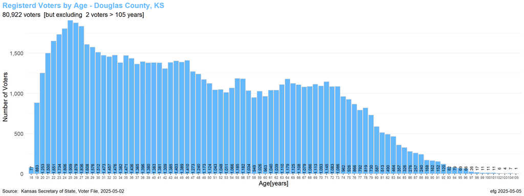

```r
TITLE <- "Registerd Voters by Age"
votersAgePlot <- PlotVoterCountsByAgeInYears(votersByAge,
                                             nrow(tooOld),
                                             TITLE,
                                             graphicsLabel)
print(votersAgePlot)
```

```r
svg( paste0(params$GEONAME,"-Registered-Voters-by-Year-of-Age.svg"), width = 16, height = 6, pointsize = 10)
print(votersAgePlot)
dev.off()
```

```r
write_xlsx(votersByAge, paste0(params$GEONAME, "-Registered-Voters-by-Year-of-Age.xlsx"))
```

# 5 Age by 5-Year Interval

Total, Inactive, Active

```r
ageInterval <-
  voters                    |>
  filter(!is.na(Age))       |>
  group_by(AgeInterval)     |>
  summarize(
            Voters   = n(),
            Active   = sum(cde_registrant_status == "A"),
            Inactive = sum(cde_registrant_status == "I")
           )

ageInterval <-
  bind_cols(ageInterval, Census = CensusTotalMark$CensusTotal)

ageInterval <-
  bind_rows(ageInterval,

            data.frame(as.list(colSums(ageInterval[,-1]) )) |>
            mutate(AgeInterval = "Total")
            )                                               |>
  mutate(
         `% Inactive`   = round(100 * Inactive / Voters, 2),
         `% Registered` = round(100 * Voters   / Census, 2)
        )                                                   |>
 select(AgeInterval, Census, Voters, `% Registered`, Active, Inactive, `% Inactive`)

ageInterval |>  Show(bigMark = ",")
```

| AgeInterval | Census | Voters | % Registered | Active | Inactive | % Inactive |
| --- | --- | --- | --- | --- | --- | --- |
| 18-19 | 7,497 | 960 | 12.81 | 933 | 27 | 2.81 |
| 20-24 | 20,708 | 7,944 | 38.36 | 6,862 | 1,082 | 13.62 |
| 25-29 | 8,936 | 8,808 | 98.57 | 6,694 | 2,114 | 24.00 |
| 30-34 | 7,736 | 7,300 | 94.36 | 5,855 | 1,445 | 19.79 |
| 35-39 | 8,282 | 7,048 | 85.10 | 6,115 | 933 | 13.24 |
| 40-44 | 6,240 | 6,861 | 109.95 | 6,221 | 640 | 9.33 |
| 45-49 | 5,805 | 6,485 | 111.71 | 5,983 | 502 | 7.74 |
| 50-54 | 5,518 | 5,292 | 95.90 | 4,877 | 415 | 7.84 |
| 55-59 | 6,061 | 5,376 | 88.70 | 5,040 | 336 | 6.25 |
| 60-64 | 5,487 | 5,331 | 97.16 | 5,016 | 315 | 5.91 |
| 65-69 | 5,768 | 5,511 | 95.54 | 5,285 | 226 | 4.10 |
| 70-74 | 4,010 | 5,369 | 133.89 | 5,199 | 170 | 3.17 |
| 75-79 | 2,397 | 4,133 | 172.42 | 4,018 | 115 | 2.78 |
| 80-84 | 2,047 | 2,411 | 117.78 | 2,327 | 84 | 3.48 |
| 85+ | 1,459 | 2,093 | 143.45 | 1,984 | 109 | 5.21 |
| Total | 97,951 | 80,922 | 82.61 | 72,409 | 8,513 | 10.52 |

```r
write_xlsx(ageInterval, paste0(params$GEONAME, "-", "Graphic-Age-Census-Active-Inactive-Voter.xlsx"))
```

```r
totalLine <-
  ageInterval |>
  filter(AgeInterval == "Total")
```

```r
plotData <-
  ageInterval |> filter(row_number() <= n() - 1) |>  # Remove last row
  select(AgeInterval, Active, Inactive)                                       |>
  pivot_longer(!AgeInterval, names_to = "Status", values_to = "Voters")       |>
  mutate(Status = factor(Status, levels = c("Inactive", "Active")))
```

```r
CensusRegistration  <-
  tibble(
          x       = 1:length(IntervalRange),
          y       = ageInterval$Voters[-nrow(ageInterval)],
          Percent = paste0(ageInterval$`% Registered`[-nrow(ageInterval)], "%")
        )
```

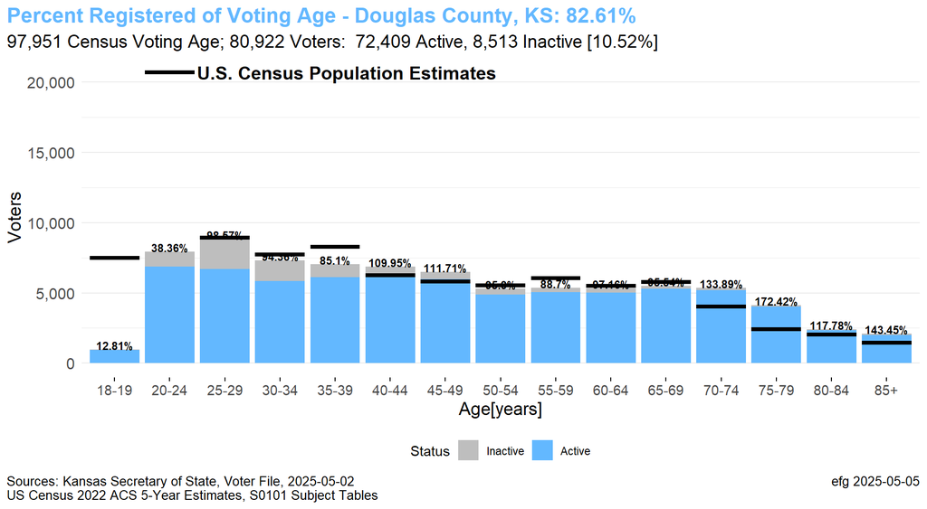

```r
TITLE <- "Percent Registered of Voting Age"

ageIntervalPlot <-
  ggplot()  +
  geom_bar(data = plotData,
           aes(x    = AgeInterval,
               y    = Voters,
               fill = Status,
               group = Status),
            show.legend = TRUE,
            stat = "identity" )                               +
  scale_y_continuous("Voters", labels = scales::comma)        +
  scale_fill_manual(values = c("grey", "steelblue1"))            +
  theme(
         axis.text          = element_text(size = 10),
         axis.ticks.x       = element_line(),
         panel.grid.major.x = element_blank(),
         legend.position = "bottom"
       )                                                      +
  labs(title = paste0(TITLE, " - ", graphicsLabel, ": ", totalLine$`% Registered`, "%"),
       subtitle = paste0(comma(as.numeric(totalLine["Census"])), " Census Voting Age; ",
                         comma(nrow(voters)), " Voters:  ",
                         comma(statusStats["A"]), " Active, ",
                         comma(statusStats["I"]), " Inactive",
                         " [", totalLine$`% Inactive`, "%", "]"),
       x = "Age[years]",
       y = "Number of Voters",
       caption = c(paste0("Sources: ", plotCaptionLeftSoS, "\n",
                          plotCaptionLeftCensus),
                   plotCaptionRight))     +

  geom_segment(data = CensusTotalMark,
               aes(x = x - 0.45,
                   y = CensusTotal,
                   xend = x + 0.45,
                   yend = CensusTotal),
                   color = "black",
                   size = 1.5
                  )                                           +
  geom_text(data = CensusMarkLabelTotal,
            aes(x = x, y = y),
            label = "U.S. Census Population Estimates",
            color = "black",
            fontface = "bold",
            size = 5,
            adj = 0)                                          +

  geom_text(data = CensusRegistration,
            aes(x = x,
                y = y),
                label = CensusRegistration$Percent,
                color = "black",
                fontface = "bold",
                hjust = 0.5, vjust =  0, size = 3 , angle = 0)

print(ageIntervalPlot)
```

```r
svg( paste0(params$GEONAME, "-Registered-Voters-by-Age.svg"), width = 16, height = 6, pointsize = 10)
print(votersAgePlot)
dev.off()
```

# 6 Age by Census 5-Year Interval and Gender

```r
ageGenderDataInterval <-
  voters                         |>
  filter(!is.na(Age))            |>
  group_by(AgeInterval, Gender)  |>
  summarize(Counts = n(),
            .groups = "drop")

ageGenderDataIntervalWide <-
  ageGenderDataInterval  |>
  spread(Gender, Counts, fill = 0)

if (!("U" %in% names(ageGenderDataIntervalWide)))
{
  ageGenderDataIntervalWide$U <- 0
}

ageGenderDataIntervalWide  |>  Show(bigMark = ",")
```

| AgeInterval | F | M | U |
| --- | --- | --- | --- |
| 18-19 | 468 | 420 | 72 |
| 20-24 | 4,009 | 3,517 | 418 |
| 25-29 | 4,495 | 4,085 | 228 |
| 30-34 | 3,717 | 3,492 | 91 |
| 35-39 | 3,522 | 3,469 | 57 |
| 40-44 | 3,499 | 3,329 | 33 |
| 45-49 | 3,267 | 3,194 | 24 |
| 50-54 | 2,706 | 2,575 | 11 |
| 55-59 | 2,767 | 2,593 | 16 |
| 60-64 | 2,870 | 2,444 | 17 |
| 65-69 | 3,078 | 2,418 | 15 |
| 70-74 | 2,871 | 2,490 | 8 |
| 75-79 | 2,219 | 1,911 | 3 |
| 80-84 | 1,384 | 1,027 | 0 |
| 85+ | 1,269 | 820 | 4 |

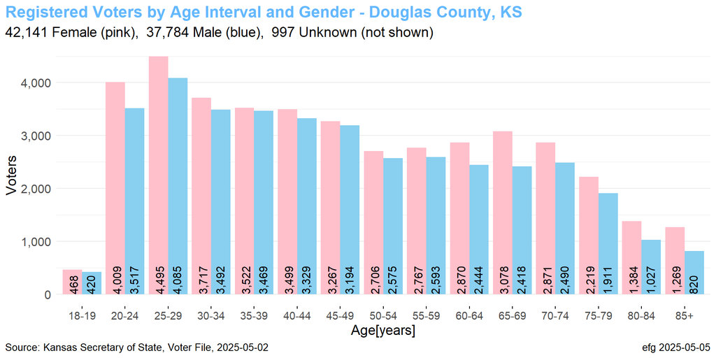

```r
TITLE = "Registered Voters by Age Interval and Gender"

registeredVotersByGenderPlot <-
  PlotVoterCountsByAgeIntervals(ageGenderDataInterval,
                                ageGenderDataIntervalWide,
                                TITLE,
                                graphicsLabel)
print(registeredVotersByGenderPlot)
```

```r
svg( paste0(params$GEONAME, "-Registered-Voters-by-Age-and-Gender.svg"), width = 10, height = 5, pointsize = 10)
print(registeredVotersByGenderPlot)
dev.off()
```

## 6.1 Comparison to Census intervals

```r
registeredVotersByGenderPlotwithCensus <-
  registeredVotersByGenderPlot                  +

     geom_segment(data = CensusMaleMark,
                 aes(x = x,
                     y = CensusMale,
                     xend = x + 0.4,
                     yend = CensusMale),
                     color = "black",
                     size = 1.5
                    )                           +
    geom_segment(data = CensusFemaleMark,
                 aes(x = x - 0.45,
                     y = CensusFemale,
                     xend = x - 0.05,
                     yend = CensusFemale),
                     color = "black",
                     size = 1.5
                    )                           +
    geom_text(data = CensusMarkLabelMaleFemale,
              aes(x = x, y = y),
              label = "U.S. Census Population Estimates",
              color = "black",
              fontface = "bold",
              size = 5,
              adj = 0)                          +
  labs(caption = c(paste0("Sources: ", plotCaptionLeftSoS, "\n",
                            plotCaptionLeftCensus),
                     plotCaptionRight))
```

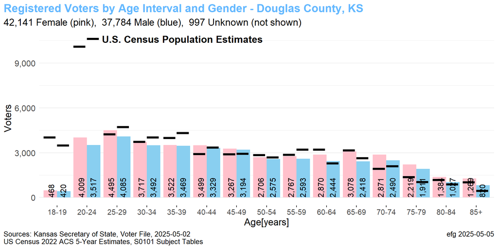

```r
print(registeredVotersByGenderPlotwithCensus)
```

```r
svg( paste0(params$GEONAME, "-Registered-Voters-by-Age-and-Gender-", params$SUBSET, ".svg"), width = 10, height = 5, pointsize = 10)
print(registeredVotersByGenderPlotwithCensus)
dev.off()
```

## 6.2 Unknown Gender Voters

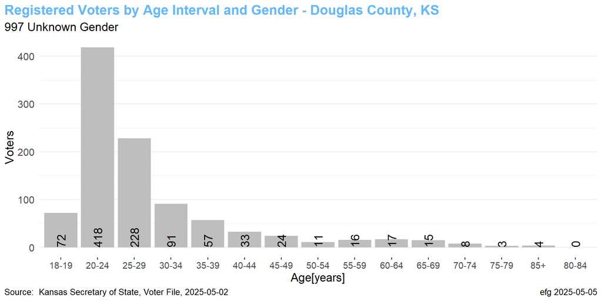

```r
if (sum(ageGenderDataIntervalWide$U) > 0)
{
  TITLE <- "Registered Voters by Age Interval and Gender"

  ageGenderDataIntervalFiltered <-
    ageGenderDataInterval       |>
    filter(Gender == "U")

    ageGenderPlotIntervalWide <-
      ggplot()  +
      geom_bar(data = ageGenderDataIntervalFiltered,
               aes(x = AgeInterval, y = Counts, fill = Gender),
               stat = "identity" )                               +
      scale_y_continuous("Voters", labels = scales::comma)        +
      theme(
             axis.text          = element_text(size = 10),
             axis.ticks.x       = element_line(),
             panel.grid.major.x = element_blank(),
             legend.position = "none"
           )                                                      +
      geom_text(aes(x = ageGenderDataIntervalWide$AgeInterval,
                    y = 0),
                    label = comma(ageGenderDataIntervalWide$U),
                hjust = 0.0, vjust = 0.5, size=5, angle = 90)    +
      scale_fill_manual(values = c("grey"))         +
      labs(title = paste(TITLE, "-", graphicsLabel),
           subtitle = paste(comma(sum(ageGenderDataIntervalWide$U)), "Unknown Gender"),
           x = "Age[years]",
           y = "Number of Voters",
           caption = c(paste("Source: ", plotCaptionLeftSoS), plotCaptionRight))

  ageGenderPlotIntervalWide

}
```

```r
colTotals <- colSums(ageGenderDataIntervalWide[,-1])
colTotals
```

```
    F     M     U
42141 37784   997
```

```r
if (! "U" %in% names(colTotals))
{
  colTotals <- c(colTotals, U = 0)
}
```

```r
colVoteSummary <- tibble(AgeInterval = "Total",
                         VoteF = colTotals["F"],
                         VoteM = colTotals["M"],
                         VoteU = colTotals["U"])
colVoteSummary |> Show()
```

| AgeInterval | VoteF | VoteM | VoteU |
| --- | --- | --- | --- |
| Total | 42141 | 37784 | 997 |

```r
graphicAgeGenderData <-
   bind_cols(ageGenderDataIntervalWide,
             CensusFemale = CensusFemaleMark$CensusFemale,
             CensusMale   = CensusMaleMark$CensusMale)

if (! "U" %in% names(graphicAgeGenderData))
{
  graphicAgeGenderData$U <- 0
}

graphicAgeGenderData  <-
  bind_rows(graphicAgeGenderData,

            data.frame(as.list(colSums(graphicAgeGenderData[,-1]) )) |>
            mutate(AgeInterval = "Total")
         )                                                           |>
  mutate(`% Female` = round(100 * F / CensusFemale, 2),
         `% Male`   = round(100 * M / CensusMale, 2),
          AgeInterval = as.character(AgeInterval))   |>
  select(AgeInterval, VoterFemale  = F, CensusFemale, `% Female`,
                      VoterMale    = M, CensusMale,   `% Male`,
                      VoterUnknown = U)

graphicAgeGenderData |> Show(bigMark = ",")
```

| AgeInterval | VoterFemale | CensusFemale | % Female | VoterMale | CensusMale | % Male | VoterUnknown |
| --- | --- | --- | --- | --- | --- | --- | --- |
| 18-19 | 468 | 4,021 | 11.64 | 420 | 3,476 | 12.08 | 72 |
| 20-24 | 4,009 | 10,094 | 39.72 | 3,517 | 10,614 | 33.14 | 418 |
| 25-29 | 4,495 | 4,225 | 106.39 | 4,085 | 4,711 | 86.71 | 228 |
| 30-34 | 3,717 | 3,720 | 99.92 | 3,492 | 4,016 | 86.95 | 91 |
| 35-39 | 3,522 | 3,978 | 88.54 | 3,469 | 4,304 | 80.60 | 57 |
| 40-44 | 3,499 | 2,902 | 120.57 | 3,329 | 3,338 | 99.73 | 33 |
| 45-49 | 3,267 | 2,881 | 113.40 | 3,194 | 2,924 | 109.23 | 24 |
| 50-54 | 2,706 | 2,845 | 95.11 | 2,575 | 2,673 | 96.33 | 11 |
| 55-59 | 2,767 | 2,852 | 97.02 | 2,593 | 3,209 | 80.80 | 16 |
| 60-64 | 2,870 | 3,202 | 89.63 | 2,444 | 2,285 | 106.96 | 17 |
| 65-69 | 3,078 | 3,144 | 97.90 | 2,418 | 2,624 | 92.15 | 15 |
| 70-74 | 2,871 | 1,920 | 149.53 | 2,490 | 2,090 | 119.14 | 8 |
| 75-79 | 2,219 | 1,370 | 161.97 | 1,911 | 1,027 | 186.08 | 3 |
| 80-84 | 1,384 | 1,171 | 118.19 | 1,027 | 876 | 117.24 | 0 |
| 85+ | 1,269 | 1,016 | 124.90 | 820 | 443 | 185.10 | 4 |
| Total | 42,141 | 49,341 | 85.41 | 37,784 | 48,610 | 77.73 | 997 |

```r
write_xlsx(graphicAgeGenderData, paste0(params$GEONAME, "-Graphic-Age-Gender-Census-Voter.xlsx"))
```

# 7 US Census Population Pyramid for Kansas

See [American Community Survey 5-Year Data (2009-2022)](https://www.census.gov/data/developers/data-sets/acs-5year.html).

# 8 Age of Voters by 5-Year Age Interval and Gender by Party

Scale separately by party

```r
table(voters$desc_party, useNA = "ifany")
```

```
      Democratic      Libertarian No Labels Kansas       Republican
           36437             1008              241            20509
    Unaffiliated    United Kansas
           22701               26
```

```r
plotParty <- function(PARTY, TITLE, LABEL)
{
  ageGenderDataIntervalParty <-
    voters                         |>
    filter(!is.na(Age),
           desc_party == PARTY)    |>
    group_by(AgeInterval, Gender)  |>
    summarize(Counts = n(),
              .groups = "drop")

  # KLUDGE fix so zero bars not plotted with wrong color and height
  fullGrid <-
    expand.grid(AgeInterval = droplevels(ageGenderDataIntervalParty$AgeInterval),
                Gender      = unique(ageGenderDataIntervalParty$Gender),
                stringsAsFactors = FALSE) |>
     unique() |>
     arrange(AgeInterval, Gender)

  ageGenderDataIntervalParty <-
    fullGrid |>
    left_join(ageGenderDataIntervalParty,
              by = join_by(AgeInterval, Gender))

fullGrid |>
  left_join(ageGenderDataIntervalParty,
            by = join_by(AgeInterval, Gender))

  # KLUDGE to fix problem with zeros

  ageGenderDataIntervalWideParty <-
    ageGenderDataIntervalParty     |>
    spread(Gender, Counts, fill = 0)

  ageGenderDataIntervalWideParty  |>  Show(bigMark = ",")

  #print( colSums(ageGenderDataIntervalWideParty[,-1]))  # Don't do this or ggplot may not appear when knitted

  registeredVotersByGenderPartyPlot <-
    PlotVoterCountsByAgeIntervals(ageGenderDataIntervalParty,
                                  ageGenderDataIntervalWideParty,
                                  TITLE, paste(LABEL, "-", PARTY))

  registeredVotersByGenderPartyPlot
}
```

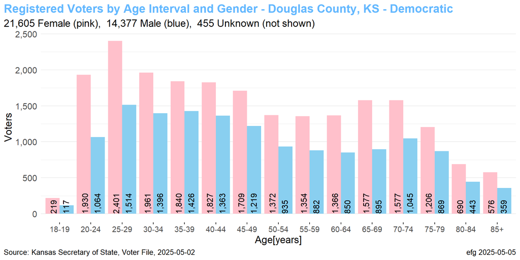

```r
TITLE <- "Registered Voters by Age Interval and Gender"
PARTY <- "Democratic"

partyPlot <- plotParty(PARTY, TITLE, graphicsLabel)

print(partyPlot)

svg( paste0(params$GEONAME, "-Registered-Voters-by-Age-and-Gender-",
            params$SUBSET, "-", PARTY, ".svg"), width = 10, height = 5, pointsize = 10)
print(partyPlot)
dev.off()
```

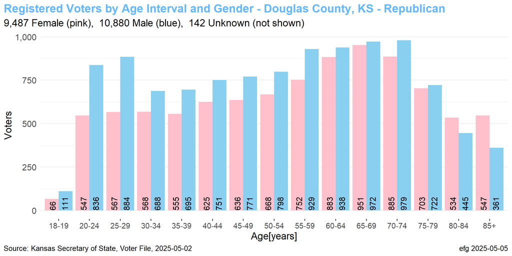

```r
PARTY <- "Republican"
partyPlot <- plotParty(PARTY, TITLE, graphicsLabel)

print(partyPlot)

svg( paste0(params$GEONAME, "-Registered-Voters-by-Age-and-Gender-",
            params$SUBSET, "-", PARTY, ".svg"), width = 10, height = 5, pointsize = 10)
print(partyPlot)
dev.off()
```

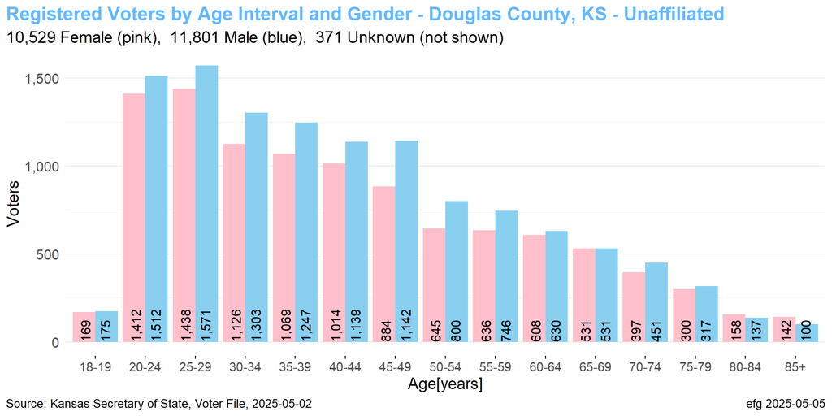

```r
PARTY <- "Unaffiliated"
partyPlot <- plotParty(PARTY, TITLE, graphicsLabel)

print(partyPlot)

svg( paste0(params$GEONAME, "-Registered-Voters-by-Age-and-Gender-",
            params$SUBSET, "-", PARTY, ".svg"), width = 10, height = 5, pointsize = 10)
print(partyPlot)
dev.off()
```

**UNCLEAR** why `ggplots` won’t appear here inline inside an `if` statement when processed as a parameterized file from the driver.

But the SVG versions of the graphics are still created.

```r
if (partyStats["Libertarian"] > 10)
{
  PARTY <- "Libertarian"
  partyPlot <- plotParty(PARTY, TITLE, graphicsLabel)

  print(partyPlot)

  svg( paste0(params$GEONAME, "-Registered-Voters-by-Age-and-Gender-",
              params$SUBSET, "-", PARTY, ".svg"), width = 10, height = 5, pointsize = 10)
  print(partyPlot)
  dev.off()
}
```

```r
if (!is.na(partyStats["No Labels Kansas"])  & partyStats["No Labels Kansas"] > 10)
{
  PARTY <- "No Labels Kansas"
  partyPlot <- plotParty(PARTY, TITLE, graphicsLabel)

  print(partyPlot)

  svg( paste0("Kansas-Registered-Voters-by-Age-and-Gender-",
              params$SUBSET, "-", str_replace_all(PARTY, " ", "-"), ".svg"), width = 10, height = 5, pointsize = 10)
  print(partyPlot)
  dev.off()
} else {
  partyStats["No Labels Kansas"]
}
```

```r
if (!is.na(partyStats["United Kansas"])  & partyStats["United Kansas"] > 10)
{
  PARTY <- "United Kansas"
  partyPlot <- plotParty(PARTY, TITLE, graphicsLabel)

  print(partyPlot)

  svg( paste0("Kansas-Registered-Voters-by-Age-and-Gender-",
              params$SUBSET, "-", str_replace_all(PARTY, " ", "-"), ".svg"), width = 10, height = 5, pointsize = 10)
  print(partyPlot)
  dev.off()
} else {
  partyStats["United Kansas"]
}
```

# 9 Epilog

## 9.1

Processing time: 6.7 secs 2025-05-05 2151